# Validación de Supuestos del Modelo de Regresión Lineal

# 1 Introducción

Este documento muestra algunas pruebas que se deben realizar sobre un modelo de regresión lineal (OLS), para validar algunos de los supuestos.

Utilizando un caso práctico, se analizan los supuestos de:

- Homoscedasticidad
- Multicolinealidad
- Normalidad de residuos

# 2 Carga de datos y paquetes

```r
# Si no los tiene instalados los paquetes "janitor", lmtest", sandwich", "readxl" y "car", debe primero instalarlos.

library(janitor)
library (readxl)
library(lmtest)
library(sandwich)
library(car)

# URL RAW del archivo en GitHub
url <- "https://raw.githubusercontent.com/edwinbhec5-glitch/Apr_Est_I/main/Basesalarios.xlsx"

# Descargar a un archivo temporal
temp_file <- tempfile(fileext = ".xlsx")
download.file(url, destfile = temp_file, mode = "wb")

# Leer con read_excel
Base <- read_excel(temp_file)

# Vista previa
head(Base)
```

```
# A tibble: 6 × 13
  Salario Horas    CI Conocimiento Escolaridad Experiencia `Tiempo nombramiento`
    <dbl> <dbl> <dbl>        <dbl>       <dbl>       <dbl>                 <dbl>
1     769    40    93           35          12          11                     2
2     808    50   119           41          18          11                    16
3     825    40   108           46          14          11                     9
4     650    40    96           32          12          13                     7
5     562    40    74           27          11          14                     5
6    1400    40   116           43          16          14                     2
# ℹ 6 more variables: Edad <dbl>, Casado <dbl>, `Minoría étnica` <dbl>,
#   Urbano <dbl>, `Escolaridad madre` <dbl>, `Escolaridad padre` <dbl>
```

```r
#Limpiar nombres variables
Base <- clean_names(Base)

#Eliminar valores perdidos que variables que intervienen en el modelo
vars <- c("salario", "escolaridad", "ci", "conocimiento",
"escolaridad_padre", "escolaridad_madre", "experiencia")

Base2 <- Base[complete.cases(Base[ , vars]), ]
```

# 3 Modelo de regresión lineal ejemplo para pruebas

Para ello se utiliza un ejemplo de los determinantes del salario, utilizando variables individuales como la escolaridad, el coeficiente intelectual (CI), la experiencia y el nivel educativo de los padres.

Como la variable dependiente tiene sesgo (algo común cuando se analiza el salario) utilizamos el logaritmo del salario como variable dependiente y como variables explicativas estarán un conjunto de 6 variables independientes

$$ln(y) = \beta_0 + \beta_1 X_1+ \beta_2 X_2 + \dots$$
Donde: $y$ representa el salario, $X_1$ es la escolaridad, $X_2$ el coeficiente intelectual, $X_3$ representa el conocimiento, $X_4$ es la escolaridad del padre, $X_5$ es la escolaridad de la madre; y, $X_6$ los años de experiencia.

```r
mod1 <- lm(log(salario) ~ escolaridad + ci + conocimiento + escolaridad_padre + escolaridad_madre + experiencia, data = Base2)
summary(mod1)
```

```
Call:
lm(formula = log(salario) ~ escolaridad + ci + conocimiento +
    escolaridad_padre + escolaridad_madre + experiencia, data = Base2)

Residuals:
     Min       1Q   Median       3Q      Max
-2.03179 -0.22296  0.02054  0.25463  1.30722

Coefficients:
                  Estimate Std. Error t value Pr(>|t|)
(Intercept)       5.168324   0.135684  38.091  < 2e-16 ***
escolaridad       0.041887   0.008844   4.736 2.62e-06 ***
ci                0.004117   0.001189   3.463 0.000566 ***
conocimiento      0.006668   0.002161   3.085 0.002115 **
escolaridad_padre 0.009312   0.005480   1.699 0.089700 .
escolaridad_madre 0.007364   0.006254   1.178 0.239383
experiencia       0.019818   0.003839   5.163 3.15e-07 ***
---
Signif. codes:  0 '***' 0.001 '**' 0.01 '*' 0.05 '.' 0.1 ' ' 1

Residual standard error: 0.379 on 715 degrees of freedom
Multiple R-squared:   0.19, Adjusted R-squared:  0.1832
F-statistic: 27.95 on 6 and 715 DF,  p-value: < 2.2e-16
```

Luego de correr la regresión y analizar los resultados se deben verificar algunos de los supuestos que tienen los modelos de regresión lineal (OLS), para determinar si dichos supuestos se cumplen o se requiere llevar a cabo algún ajuste al modelo.

# 4 Comprobación de Supuestos

## 4.1 Heteroscedasticidad

La heteroscedasticidad en un modelo de regresión lineal ocurre cuando la varianza del término de error no es constante a lo largo de las observaciones, sino que depende del nivel de alguna variable explicativa (Variables X´s). Esta situación viola uno de los supuestos clásicos del modelo (la homocedasticidad), lo que implica que, los coeficientes calculados dejan de ser eficientes y ya no presentan la mínima varianza.

En la práctica, la heteroscedasticidad distorsiona la inferencia estadística: los errores estándar estimados son incorrectos, lo que afecta directamente a los estadísticos t, F y a los intervalos de confianza. En consecuencia, se pueden obtener conclusiones erróneas sobre la significancia de las variables explicativas. Por ello, su detección y corrección —mediante errores estándar robustos, transformaciones de variables o métodos alternativos es fundamental para garantizar una inferencia válida.

### 4.1.1 Test de Homoscedasticidad

Para la prueba de homocedasticidad usamos el Test de Breusch-Pagan, donde se plantea como hipótesis nula, la **no violación del supuesto (H0: Homocedasticidad)**.

```r
bptest(mod1)
```

```
    studentized Breusch-Pagan test

data:  mod1
BP = 11.69, df = 6, p-value = 0.06925
```

En este caso el p-value es de 0.07, por lo que no se puede Rechazar H0. Esto significa que los residuos son **Homoscedásticos** y se cumple el supuesto.

### 4.1.2 Corrección de heterocedasticidad con errores robustos

Sin embargo, cuando se trabaja con datos de cohorte transversal (como ocurre con muchas encuestas) es recomendable utilizar errores estandar robustos, incluso aunque los residuos sean homocedásticos (aunque el p-value del test de Breusch-Pagan sea mayor a 0.05)

Por otro lado, cuando se rechace H0 (p-value menor a 0.05), es **indispensable** utilizar errores estándar robustos para corregir el problema de heteroscedasticidad.

```r
coeftest(mod1, vcov = vcovHC)
```

```
t test of coefficients:

                   Estimate Std. Error t value  Pr(>|t|)
(Intercept)       5.1683240  0.1331041 38.8292 < 2.2e-16 ***
escolaridad       0.0418869  0.0097784  4.2836 2.090e-05 ***
ci                0.0041167  0.0011443  3.5975 0.0003434 ***
conocimiento      0.0066678  0.0023768  2.8054 0.0051624 **
escolaridad_padre 0.0093119  0.0057731  1.6130 0.1071898
escolaridad_madre 0.0073637  0.0062406  1.1800 0.2384015
experiencia       0.0198183  0.0039923  4.9641 8.637e-07 ***
---
Signif. codes:  0 '***' 0.001 '**' 0.01 '*' 0.05 '.' 0.1 ' ' 1
```

Los coeficientes estimados no cambian, pero sí cambian los errores estándar de cada coeficiente y por ende sus valores t y sus p-values. Sin embargo estos nuevos valores corrigen los problemas (o potenciales problemas) causados por la heteroscedasticidad.

## 4.2 Multicolinealidad

La multicolinealidad en un modelo de regresión lineal se presenta cuando dos o más variables explicativas están altamente correlacionadas entre sí, lo que dificulta identificar de manera precisa el efecto individual de cada una sobre la variable dependiente. Aunque la multicolinealidad no viola los supuestos clásicos del modelo, sí genera problemas en la estimación, ya que incrementa la varianza de los estimadores de los coeficientes, volviéndolos inestables y muy sensibles a pequeños cambios en la muestra.

El principal inconveniente práctico de la multicolinealidad es que reduce la precisión de la inferencia estadística: los errores estándar se inflan, los estadísticos t tienden a ser bajos y variables que son teóricamente relevantes pueden aparecer como no significativas. Esto puede llevar a interpretaciones erróneas sobre la importancia de los regresores, aun cuando el modelo tenga un buen ajuste global. Por esta razón, es clave diagnosticarla (por ejemplo, mediante factores de inflación de la varianza, VIF) y, de ser necesario, aplicar estrategias como la redefinición de variables, la eliminación de regresores redundantes o el uso de técnicas alternativas de estimación.

### 4.2.1 Prueba de inflación de la varianza (VIF)

```r
vif(mod1)
```

```
      escolaridad                ci      conocimiento escolaridad_padre
         1.963674          1.547680          1.382543          1.646896
escolaridad_madre       experiencia
         1.570345          1.335143
```

**Regla práctica:** Se deben observar los factores de inflación asociados a cada variable, bajo el siguiente criterio:

- VIF ≈ 1: sin multicolinealidad.
- VIF > 5: multicolinealidad moderada.
- VIF > 10: multicolinealidad severa.

En este ejercicios no se observa que ninguna variable supere los umbrales de vif de 5 o 10, por lo que podemos concluir que **no existen problemas de multicolinealidad**.

**Qué pasa si hay VIF grandes:** Si se considera que existen **variables altamente correlacionadas que pueden ser redundantes** (VIF superiores a 5 o 10) debe eliminarse una de esas variables. Sin embargo, antes de hacerlo se debe analizar si eliminar dicha variable no va en contra de algún sustento teórico, es decir, si la teoría indica que la(s) variable(s) **debe(n)** estar en el modelo su eliminacíon debe ser más cautelosa.

## 4.3 Normalidad de los residuos

Las pruebas de normalidad de los residuos en un modelo de regresión lineal se utilizan para evaluar si el término de error sigue una distribución normal, un supuesto clave para la validez de la inferencia estadística en muestras pequeñas. Aunque la normalidad de los residuos no es necesaria para que los estimadores del modelo sean insesgados y consistentes, sí es fundamental para que los estadísticos t y F tengan exactamente las distribuciones teóricas que permiten realizar contrastes de hipótesis y construir intervalos de confianza fiables.

El principal problema cuando los residuos no son normales es que la inferencia puede volverse imprecisa, especialmente en muestras reducidas o en presencia de valores atípicos y asimetrías pronunciadas. En estos casos, las pruebas de significancia pueden estar sesgadas y llevar a conclusiones incorrectas. Por ello, es habitual complementar las pruebas formales de normalidad (como Jarque–Bera o Shapiro–Wilk) con análisis gráficos y, si es necesario, recurrir a transformaciones de variables que reduzcan la dependencia de este supuesto.

### 4.3.1 Prueba Jarque-Bera

El test de Jarque-Bera sirve para analizar si los residuos del modelo estimado siguen una distribución normal. La hipótesis nula que se plantea es que los residuos siguen una distribución normal, es decir, H0: residuos normales.

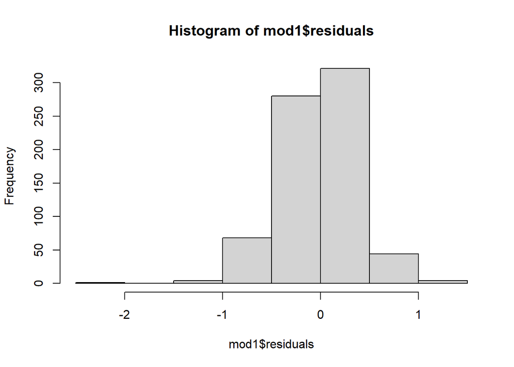

```r
hist(mod1$residuals)
```

```r
library(tseries)
jarque.bera.test(mod1$residuals)
```

```
    Jarque Bera Test

data:  mod1$residuals
X-squared = 71.582, df = 2, p-value = 3.331e-16
```

En este caso, utilizando la prueba Jarque-Bera **se Rechaza H0, ya que el p-value es muy pequeño**. No obstante, dado el tamaño muestral y que la normalidad no es un requisito para la consistencia de los estimadores OLS, esto no cambia los resultados, pero es recomienda reportar la **no normalidad de los residuos**

## 4.4 Otras validaciones (sección complementaria)

Las siguientes pruebas no son obligatorias en todos los modelos, pero pueden ser relevantes según el contexto:

### 4.4.1 Autocorrelación de residuos

dwtest(modelo)

Útil principalmente en datos de series de tiempo o panel.

### 4.4.2 Observaciones influyentes

plot(cooks.distance(modelo), type = “h”)

Permite identificar observaciones con influencia desproporcionada en la estimación.

### 4.4.3 Especificación funcional (RESET)

resettest(modelo)

Evalúa si la forma funcional del modelo está correctamente especificada.

## 4.5 Qué NO debe hacerse

- Aplicar pruebas sin interpretar sus resultados.
- Eliminar variables únicamente por problemas de multicolinealidad.
- Rechazar un modelo solo por no cumplir normalidad en muestras grandes.